# **A Transformer-Based Framework for Geomagnetic Activity Prediction**

# **Table of Contents**

7 References

### **Author(s)**

- Author1 = {"name": "Yasser Abduallah", "affiliation": "Department of Computer Science, New Jersey Institute of Technology", "email": "ya54@njit.edu", "orcid": "https://orcid.org/0000-0003-0792-2270%22%7D
- Author2 = {"name": "Jason T. L. Wang", "affiliation": "Department of Computer Science, New Jersey Institute of Technology", "email": "wangj@njit.edu", "orcid": "https://orcid.org/0000-0002-2486-1097%22%7D
- Author3 = {"name": "Chunhui Xu", "affiliation": "Department of Computer Science, New Jersey Institute of Technology", "email": "cx4@njit.edu", "orcid": ""}
- Author = {"name": "Haimin Wang", "affiliation": "Institute for Space Weather Sciences, New Jersey Institute of Technology", "email": "haimin.wang@njit.edu", "orcid": "https://orcid.org/0000-0002-5233-565X%22%7D

### **Purpose**

Geomagnetic activities have a crucial impact on Earth, which can affect spacecraft and electrical power grids. Geospace scientists use a geomagnetic index, called the Kp index, to describe the overall level of geomagnetic activity. This index is an important indicator of disturbances in the Earth's magnetic field and is used by the U.S. Space Weather Prediction Center as an alert and warning service for users who may be affected by the disturbances. Early and accurate prediction of the Kp index is essential for preparedness and disaster risk management. In this paper, we present a novel deep learning method, named KpNet, to perform short-term, 1-9 hour ahead, forecasting of the Kp index based on the solar wind parameters taken from the NASA Space Science Data Coordinated Archive. KpNet combines transformer encoder blocks with Bayesian inference, which is capable of quantifying both aleatoric uncertainty (data uncertainty) and epistemic uncertainty (model uncertainty) when making Kp predictions. Experimental results show that KpNet outperforms closely related machine learning methods in terms of the root mean square error and R-squared score. Furthermore, KpNet can provide both data and model uncertainty quantification results, which the existing methods cannot offer. To our knowledge, this is the first time that Bayesian transformers have been used for Kp prediction.

In this notebook we provide an overview of the KpNet model to demonstrate how to forecast Kp index using deep learning (DL) and solar wind parameters and provide uncertatinty quantification with Bayesian network.

### **Technical Contributions**

- We provide the community with a new tool to forecast the occurrance of the planetary Kp index for the next 1, 2, 3, 4, 5, 6, 7, 8, or 9 hours ahead. The tools also provide data and model uncertainty quantification.

### **Methodology**

The biLSTM layer transfers the learned patterns down to a transformer network, which is composed of $b$ transformer encoder blocks (TEBs) (we set $b$ to 8 in this study). Each TEB consists of a multi-head attention layer, a batch normalization layer, and a feed-forward network. Generally, transformers for natural language processing (NLP) use layer normalization leading to significant performance gains over batch normalization. However, we use batch normalization here to avoid the effect of outliers in time series which do not exist in NLP word embedding. The multi-head attention layer provides transformation on the sequential input values to obtain distinct metrics of size $h$. Here, $h$ is the number of attention heads that is set to 4 and the size of each attention head is also set to 4; the other parameters are left with their default values. The feed-forward network, composed of a Conv1D layer, with 4 kernels where the number of kernels equals the number of attention heads and each kernel size is 1, followed by a biLSTM layer with 250 neurons, helps reduce over-fitting. Notice that each TEB uses a transformer encoder without the decoder because we are dealing with time series instead of language processing and therefore translation is not involved.

[figure not shown]

(a)

[figure not shown]

(b)

#### Uncertainty Quantification

This notebook leverages python deep learning to describe the steps on how to use the KpNet tool to forecast the Kp index for 1 to 9 hours ahead.

### **Funding**

This work was supported by U.S. NSF grants AGS-1927578 and AGS-1954737 and supported by NASA under grants 80NSSC18K1705, 80NSSC19K0068, and 80NSSC20K1282.

### **Keywords**

keywords=["Kp","Index","Forecasting", "Prediction", "Machine", "Learning","Solar",'Wind"."Uncertainty","Quantification"]

### **Acknowledgements**

We acknowledge the use of NASA/GSFC’s Space Physics Data Facility’s OMNIWeb service and OMNI data

# **Setup**

**Installation on Local Machine**  
Running this notebook in a local machine requires Python version 3.9.x with the following packages and their version:

| Library | Version | Description |
| --- | --- | --- |
| keras | 2.8.0 | Deep learning API |
| numpy | 1.22.4 | Array manipulation |
| scikit-learn | 1.0.2 | Machine learning |
| sklearn | latest | Tools for predictive data analysis |
| matlabplot | 3.5.1 | Visutalization tool |
| pandas | 1.4.1 | Data loading and manipulation |
| seaborn | 0.11.2 | Visualization tool |
| scipy | 1.8.1 | Provides algorithms for optimization and statistics |
| tensorflow | 2.8.0 | Comprehensive, flexible ecosystem of tools and libraries for machine learning |
| tensorflow-gpu | 2.8.0 | Deep learning tool for high performance computation |
| tensorflow-probability | 0.14.1 | For probabilistic models |

**Library Import**  
The following libraries need to be imported.

```python
#supress warning messages
import warnings
warnings.filterwarnings('ignore')
print('Importing packages..')
# Data manipulation
import pandas as pd
import numpy as np
import os
print('Packages imported')
#make sure the scripts are executed in the correct pacakage location.
import sys
sys.path.append('.')
```

```
Importing packages..
Packages imported
```

# **Data Processing and Analysis**

The Kp measurements used in this study are provided by the GFZ German Research Centre for Geoscience available here: https://www.gfz-potsdam.de/en/kp-index/. The Kp values in the GFZ site are collected with a 3-hour cadence where the values range from 0 to 8.33. The solar wind parameters used in this study are taken from the NASA Space Science Data Coordinated Archive. We collect the data in the time period between January 1, 2010 and March 31, 2022. We select the time resolution of the hourly average for the solar wind parameters. We consider eight solar wind parameters, namely the interplanetary magnetic field (IMF) magnitude average, magnetic field Bx, By, and Bz components, plasma temperature, proton density, plasma speed, and flow pressure. Due to the difference in cadence, where Kp uses a 3-hour cadence whereas the solar wind parameters use a 1-hour cadence, we process the data by temporally matching the Kp measurements from the GFZ site with the solar wind parameters from the NASA site to create the final dataset.

# **Binder**

Please note that starting Binder might take some time to create and start the image.

# **KpNet Workflow and Results**

### **Data Preparation and Loading**

The data directoryr includes all training and test data sets required to run the run the notebook. The files are loaded and used during the testing and training process.

### **Predicting with Pretrained Models**

There are default and pretrained models that can be used to predict without running your own trained model. The models_directory is set to default_models which uses all pretrained algorithms.

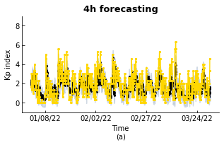

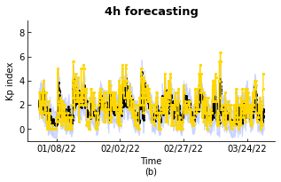

```python
#Test default models for 4hour ahead.
from KpNet_test import test

models_directory='default_models'
print('Test default models for Kp forecasting for 1-9 hours ahead.')
start_hour=4
end_hour=4
test(start_hour,end_hour+1,models_directory=models_directory)
```

**Plotting the Pretrained Models Results**  
The prediction result can be plotted using the function plot_figures. It uses the results produced by the model from the "default_results" directory.

```
Plotting figures for default models results for Kp forecasting for 1-9 hours ahead.
Graphing results for h = 1 hour ahead
Graphing results for h = 2 hour ahead
Graphing results for h = 3 hour ahead
Graphing results for h = 4 hour ahead
Graphing results for h = 5 hour ahead
Graphing results for h = 6 hour ahead
Graphing results for h = 7 hour ahead
Graphing results for h = 8 hour ahead
Graphing results for h = 9 hour ahead
```

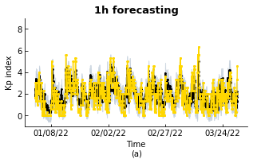

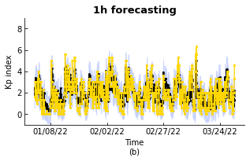

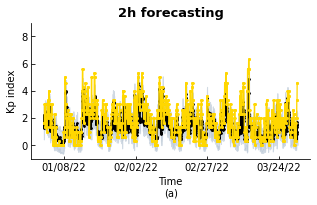

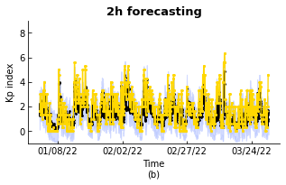

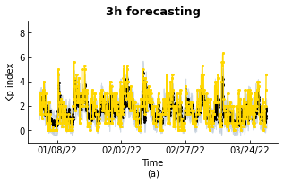

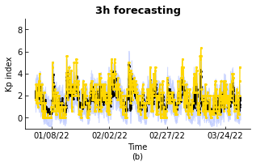

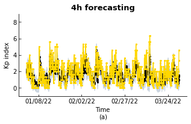

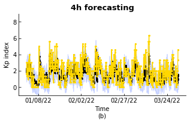

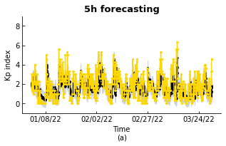

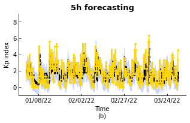

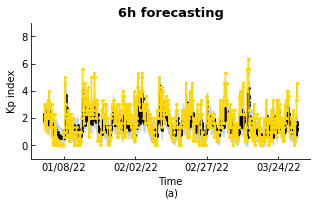

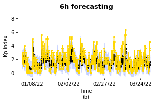

[6 more figures not shown]

[output not shown]

```python
from KpNet_plot_results_figures import plot_figures

figures_dir='default_figures'
results_dir='default_results'
print('Plotting figures for default models results for Kp forecasting for 1-9 hours ahead.')
start_hour=1
end_hour=9

plot_figures(start_hour, end_hour+1,show_figures=True,figures_dir = figures_dir,results_dir=results_dir)
```

### **KpNet Model Training and Testing Example**

```python
#Training for F 4 hour ahead on sample data.
print('Loading the train_model function...')
from KpNet_train import train_model
print('Train custom model for h=4')
start_hour=4
end_hour=4
#set the number of epochs=10
epochs=100
train_model(start_hour,end_hour+1,epochs=epochs)
```

```
Loading the train_model function...

Train custom model for h=4
Running training for h = 4 hour ahead
204/204 - 11s - loss: 66373.0469 - mse: 387.5989 - 11s/epoch - 52ms/step
204/204 - 3s - loss: 56682.9258 - mse: 367.2063 - 3s/epoch - 15ms/step
204/204 - 3s - loss: 48306.5469 - mse: 323.3544 - 3s/epoch - 15ms/step
204/204 - 3s - loss: 41160.9727 - mse: 297.5820 - 3s/epoch - 15ms/step
204/204 - 3s - loss: 35027.7266 - mse: 274.2481 - 3s/epoch - 14ms/step
204/204 - 3s - loss: 29757.8203 - mse: 260.3484 - 3s/epoch - 13ms/step
204/204 - 3s - loss: 25209.8535 - mse: 248.8583 - 3s/epoch - 13ms/step
204/204 - 3s - loss: 21275.0117 - mse: 243.4390 - 3s/epoch - 15ms/step
204/204 - 3s - loss: 17867.7734 - mse: 229.3562 - 3s/epoch - 15ms/step
204/204 - 3s - loss: 14939.6406 - mse: 229.9255 - 3s/epoch - 15ms/step
204/204 - 3s - loss: 12413.3184 - mse: 225.1177 - 3s/epoch - 15ms/step
204/204 - 3s - loss: 10244.7432 - mse: 220.3210 - 3s/epoch - 14ms/step
204/204 - 3s - loss: 8394.2734 - mse: 216.0346 - 3s/epoch - 14ms/step
204/204 - 3s - loss: 6824.9844 - mse: 215.2938 - 3s/epoch - 15ms/step
204/204 - 3s - loss: 5499.7046 - mse: 213.6460 - 3s/epoch - 14ms/step
204/204 - 3s - loss: 4391.4893 - mse: 211.2046 - 3s/epoch - 13ms/step
204/204 - 3s - loss: 3471.7366 - mse: 208.5576 - 3s/epoch - 14ms/step
204/204 - 3s - loss: 2719.0769 - mse: 207.8260 - 3s/epoch - 15ms/step
204/204 - 3s - loss: 2108.7979 - mse: 206.0529 - 3s/epoch - 14ms/step
204/204 - 3s - loss: 1616.3741 - mse: 199.7896 - 3s/epoch - 14ms/step
204/204 - 3s - loss: 1224.1727 - mse: 190.9399 - 3s/epoch - 14ms/step
204/204 - 3s - loss: 924.6888 - mse: 187.5898 - 3s/epoch - 14ms/step
204/204 - 3s - loss: 697.3514 - mse: 184.9147 - 3s/epoch - 15ms/step
204/204 - 3s - loss: 526.1557 - mse: 180.1327 - 3s/epoch - 15ms/step
204/204 - 3s - loss: 402.8741 - mse: 177.0804 - 3s/epoch - 15ms/step
204/204 - 3s - loss: 318.3642 - mse: 176.4986 - 3s/epoch - 15ms/step
204/204 - 3s - loss: 259.6706 - mse: 174.3157 - 3s/epoch - 14ms/step
204/204 - 3s - loss: 220.2583 - mse: 171.3522 - 3s/epoch - 15ms/step
204/204 - 3s - loss: 191.4297 - mse: 165.1889 - 3s/epoch - 15ms/step
204/204 - 3s - loss: 175.7243 - mse: 162.4708 - 3s/epoch - 14ms/step
204/204 - 3s - loss: 165.4170 - mse: 158.7976 - 3s/epoch - 14ms/step
204/204 - 3s - loss: 159.0907 - mse: 155.5065 - 3s/epoch - 14ms/step
204/204 - 3s - loss: 154.9366 - mse: 152.5526 - 3s/epoch - 15ms/step
204/204 - 3s - loss: 151.9982 - mse: 150.3883 - 3s/epoch - 14ms/step
204/204 - 3s - loss: 150.9710 - mse: 149.5739 - 3s/epoch - 14ms/step
204/204 - 3s - loss: 147.1706 - mse: 146.0652 - 3s/epoch - 15ms/step
```

[output cut: 48 more lines]

```
204/204 - 3s - loss: 123.9302 - mse: 123.5486 - 3s/epoch - 14ms/step
204/204 - 3s - loss: 123.6590 - mse: 123.2779 - 3s/epoch - 14ms/step
204/204 - 3s - loss: 121.9242 - mse: 121.5576 - 3s/epoch - 14ms/step
204/204 - 3s - loss: 121.7559 - mse: 121.3908 - 3s/epoch - 15ms/step
204/204 - 3s - loss: 119.0409 - mse: 118.6804 - 3s/epoch - 15ms/step
204/204 - 3s - loss: 123.4234 - mse: 123.0367 - 3s/epoch - 14ms/step
204/204 - 3s - loss: 120.1520 - mse: 119.7860 - 3s/epoch - 14ms/step
204/204 - 3s - loss: 118.9683 - mse: 118.6215 - 3s/epoch - 14ms/step
204/204 - 3s - loss: 120.0336 - mse: 119.6835 - 3s/epoch - 15ms/step
204/204 - 3s - loss: 121.2730 - mse: 120.9078 - 3s/epoch - 14ms/step
204/204 - 3s - loss: 119.0277 - mse: 118.6711 - 3s/epoch - 15ms/step
204/204 - 3s - loss: 120.2810 - mse: 119.9263 - 3s/epoch - 15ms/step
204/204 - 3s - loss: 117.7503 - mse: 117.3983 - 3s/epoch - 15ms/step
204/204 - 3s - loss: 117.3553 - mse: 117.0207 - 3s/epoch - 15ms/step
204/204 - 3s - loss: 118.9782 - mse: 118.6221 - 3s/epoch - 15ms/step
```

```
204/204 - 3s - loss: 120.1330 - mse: 119.7578 - 3s/epoch - 14ms/step
```

**Predicting with Your Trained KpNet Model**  
To predict the testing data using the model you trained above, make sure the models_directory variable is set to models:  
models_directory='models'

Note: this is training job is only an example that uses less, training proceses, epochs, therefore the results and performance metrics are not comparable to fully developed pretrained and default models.

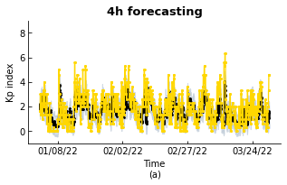

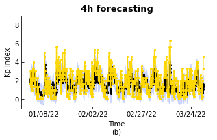

```python
#Test custom model for 4-hour ahread.
from KpNet_test import test

models_directory='models'
print('Test your trained models for Kp forecasting for 6-hour ahead.')
start_hour=4
end_hour=4
test(start_hour,end_hour+1,models_directory=models_directory)
```

**Plotting the Results for Your Trained Model**  
The prediction result can be plotted using the function plot_figures as shown in the following example. The example plots your trained model results for h=4 hours ahead.

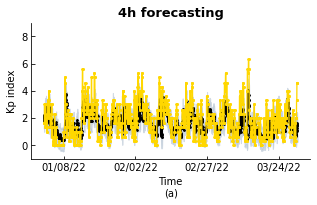

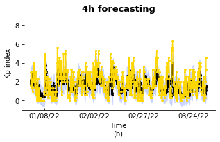

```python
from KpNet_plot_results_figures import plot_figures

figures_dir='figures'
results_dir='results'
print('Plotting figures for default models results for KP forecasting for 4 hours ahead.')
start_hour=4
end_hour=4

plot_figures(start_hour, end_hour+1,show_figures=True,figures_dir = figures_dir,results_dir=results_dir)
```

### **Timing**

Please note that the execution time in mybinder varies based on the availability of resources. The average time to run the notebook is 30-40 minutes, but it could be more.

# **Conclusions**

# **References**

1. A Transformer-Based Framework for Geomagnetic Activity Prediction  
   Yasser Abduallah, Jason T. L. Wang, Chunhui Xu, and Haimin Wang  
   https://link.springer.com/chapter/10.1007/978-3-031-16564-1_31
2. Forecasting the Disturbance Storm Time Index with Bayesian Deep Learning  
   Yasser Abduallah, Jason T. L. Wang, Prianka Bose, Genwei Zhang, Firas Gerges, and Haimin Wang  
   https://iopscience.iop.org/article/10.3847/1538-4365/ac5f56
3. DeepSun: Machine-Learning-as-a-Service for Solar Flare Prediction  
   Yasser Abduallah, Jason T. L. Wang and Haimin Wang  
   https://doi.org/10.32473/flairs.v35i.130564
4. Tracing Hα Fibrils through Bayesian Deep Learning  
   Haodi Jiang, Ju Jing, Jiasheng Wang, Chang Liu, Qin Li, Yan Xu, Jason T. L. Wang, and Haimin Wang  
   https://doi.org/10.3847/1538-4365/ac14b7
5. Dropout as a Bayesian Approximation: Representing Model Uncertainty in Deep Learning  
   Yarin Gal and Zoubin Ghahramani  
   https://dl.acm.org/doi/10.5555/3045390.3045502